# MonsterrhinoMotion

## Introduction

The MonsterrhinoMotion card is an independent stepper motor driver card to power and control up to 4 stepper motors that comes with a pre-installed firmware. The MonsterrhinoMotion card uses high quality stepper drivers (TMC5160) from Trinamic. You can use Monsterrhino Motion in different ways depending on the complexity of your project:

- Use the pre-installed library by sending commands **over a serial USB port** using a variety of predefined functions (see below)
- Use the pre-installed library by sending commands **over CAN bus** using a variety of predefined functions (see in the MonsterrhinoControl documentation)
- Program functions and actions with the **provided Arduino library** and upload directly to the card

In the simplest case all you need to do is **just connect 24V, a stepper motor and a USB cable** to the Monsterrhino Motion and you are ready to move the motor - **plug and play**.

The key features of the MonsterrhinoMotion stepper driver card are:

- up to 4 stepper motors
- two limit switches per motor
- encoder for each stepper motor
- up 12 digital inputs (24V)
- 1 digital output (24V)
- 3 PWM outputs (open collector)
- 2 CAN bus connector
- USB C connector
- micro USB connector
- analog emergency power-off circuit that can be bridged with a jumper

## MonsterrhinoMotion pinout

[figure not shown]

## USB serial communication

### Connect to Monsterrhino Motion

Install the Arduino IDE on your computer (https://www.arduino.cc/en/software). Open the Arduino IDE on your computer.

- Select the right port under **Tools->Port** e.g. /dev/ttyACM0 or COM5.
- Open the serial monitor and set **115200 baud** and line ending to **Both NL & CR**.

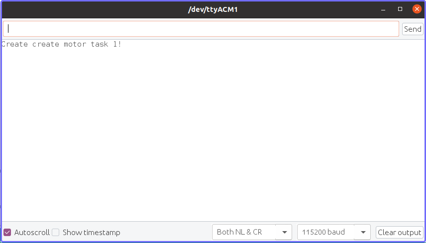

[figure not shown]

### Commands

The MonsterrhinoMotion commands are combinations of commands from the list below. They are composed of the classifier: **m, i or f**. A number after the classifier letter selects the desired motor, input, or function: Motor 1 = **m1**, Userfunction 1 = **f1**. The classifier is followed by a function such as targetposition = **tp** and a number.

- **m1tp 100** - motor 1 move to target position 100
- **m4ma 200** - motor 4 set motor current to 200 mA
- **m3smp** - motor 3 save motor parameters
- **m2cp ?** - request motor 2 current position

| motor function | **subfunction** | **subfunction** | values |
| --- | --- | --- | --- |
| TargetPosition | tp | targetpos |  |
| CurrentPosition | cp | currentpos |  |
| Rampmode | rm | rampmode | p or positioning, v or velocity, h or hold |
| Motor current | ma | currentma |  |
| MaxSpeed | ms | maxspeed |  |
| CurrentSpeed | cs | currentspeed |  |
| Register | r | register |  |
| RampSpeeds | rs | rampspeeds |  |
| Acceleration | ac | acceleration |  |
| Accelerations | as | accelerations |  |
| Stop | s | stop |  |
| Enable | en | enable |  |
| Disable | di | disable |  |
| EncoderPosition | ep | encoderposition |  |
| LatchedPosition | lp | latchedposition |  |
| LatchedEncoderPosition | le | latchedencoder |  |
| MotorDriveStatus | mds | motordrvstatus |  |
| MotorRampStat | mrs | motorrampstat |  |
| gStat | gs | gstat |  |
| MotorCurrent | ma | currentma |  |
| Freewheelingmode | fwm | freewheelingmode |  |
| ModeChangeSpeeds | mcs | modechangespeeds |  |
| Switch Mode | swm | swmode |  |
| Save | sv | save |  |
| SaveMotorParameter | smp | savemotorparameter |  |
| Test | test |  |  |
| Load | ld | load |  |
| Startup | st | startup |  |

| **input function** | subfunction | subfunction |
| --- | --- | --- |
| InputFunction | if | inputfunction |
| StartUp | st | startup |

| **system function** | subfunction | subfunction |
| --- | --- | --- |
| Start | s | start |
| Stop | t | stop |
| Variable | v | variable |
| Float | f | float |
| Startup | st | startup |
| Unlock | u | unlook |

## Program the **Monsterrhinostep library** with Arduino IDE or VisualMicro

To use the the Monsterrhinosteb-Lib (https://github.com/Monsterrhino/MonsterrhinoMotion/tree/master/Library) library it is necessary to install following packages first:

## On Windows

Tested on Windows 10.

### Install Java Runtime Environment

If not already satisfied:

- Download the Java Runtime Environment from the official Website - https://www.java.com/en/download/manual.jsp
- Install it by running the executable (.exe) file

### Prepare Arduino IDE:

- Download and install the Arduino IDE (Version 1.8.12) from the official page: https://www.arduino.cc/en/Main/Software (or get it from the Software folder)
- Start the Arduino IDE and add **Stm32duino** as follows:
  - Go to **File->Preferences**. Under the section **Additional Boards Manager URLs**:

    `https://raw.githubusercontent.com/stm32duino/BoardManagerFiles/master/STM32/package_stm_index.json`

**Note:** Please use exacatly this version, even if its deprecated

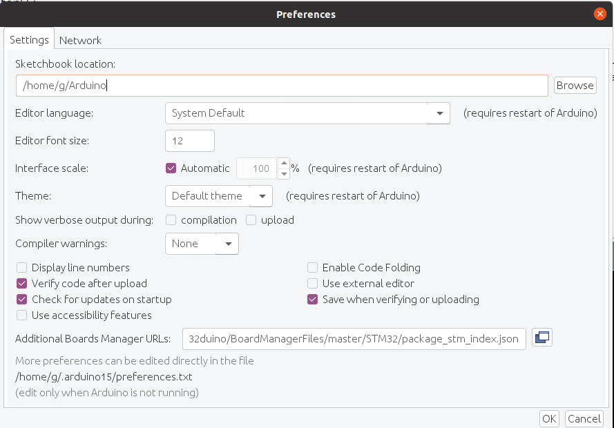

- Go to **Tools->Board->Boards Manager** and search for **STM32 Cores**, choose version **1.8.0** and press *Install*.

[figure not shown]

After that you should be able to select **Nucleo-64** under **Tools->Board**.

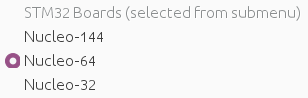

### Install STM32CubeProgrammer:

- Download **STM32CubeProgrammer** from the official page: https://www.st.com/en/development-tools/stm32cubeprog.html. You need to enter your email address for that.
- Install it by running the executable (.exe) file.
- You can install it with the default settings. During the installation process, the drivers will be installed to.
- Verify the installation by opening the programm **STM32CubeProgrammer**. If the program opens normally, everything should be fine.

*Attention*: Check if you can open the **STM32CubeProgrammer** and connect to your MonsterrhinoMotion. Select USB and **bring your MonsterrhinoMotion into boot-mode** by pressing reset while holding down the boot button. After successfully connecting to your device you should see something similar to:

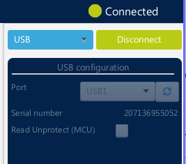

### Following files need to be replaced inside the Arduino folder

Replace following two files on your computer with the files you find inside the https://github.com/Monsterrhino/MonsterrhinoMotion/tree/master/Library/Replace folder:

- Replace **usbd_cdc_if.c** inside:  
  `C:\Users\username\AppData\Local\Arduino15\packages\STM32\hardware\stm32\1.8.0\cores\arduino\stm32\usb\cdc` **or** `C:\Users\username\Documents\ArduinoData\packages\STM32\hardware\stm32\1.8.0\cores\arduino\stm32\usb\cdc`  
  **-** depending on location of your installation (it could also be a different location).
- Replace **variant.c** inside:  
  `C:\Users\username\AppData\Local\Arduino15\packages\STM32\hardware\stm32\1.8.0\variants\NUCLEO_L476RG` **or** `C:\Users\username\Documents\ArduinoData\packages\STM32\hardware\stm32\1.8.0\variants\NUCLEO_L476RG`  
  **-** depending on location of your installation (it could also be a different location).

### Add the **STM32duino_FreeRTOS.zip** to the Arduino IDE:

The **STM32duino_FreeRTOS.zip** can be found here: https://github.com/Monsterrhino/MonsterrhinoMotion/tree/master/Library. Download it and add **STM32duino_FreeRTOS.zip** to the Arduino IDE libraries from the menu **Sketch->Include Library->Add ZIP Library**.

### Add the **MonsterrhinoStep-Lib** to the Arduino IDE:

To add the **MonsterrhinoStep-Lib** to the Arduino IDE download the **MonsterrhinoStep-Lib.zip** from https://github.com/Monsterrhino/MonsterrhinoMotion/tree/master/Library and proceed with following steps:

- Open the Arduino IDE, for each libary inside the Libs folder go to **Sketch->IncludeLibrary->Add .ZIP Library ..** and select the **MonsterrhinoStep-Lib.zip** file.
- Open the Monsterrhino application in your Arduino IDE: **File->Examples->Monsterrhinostep->monsterrhinostep**.

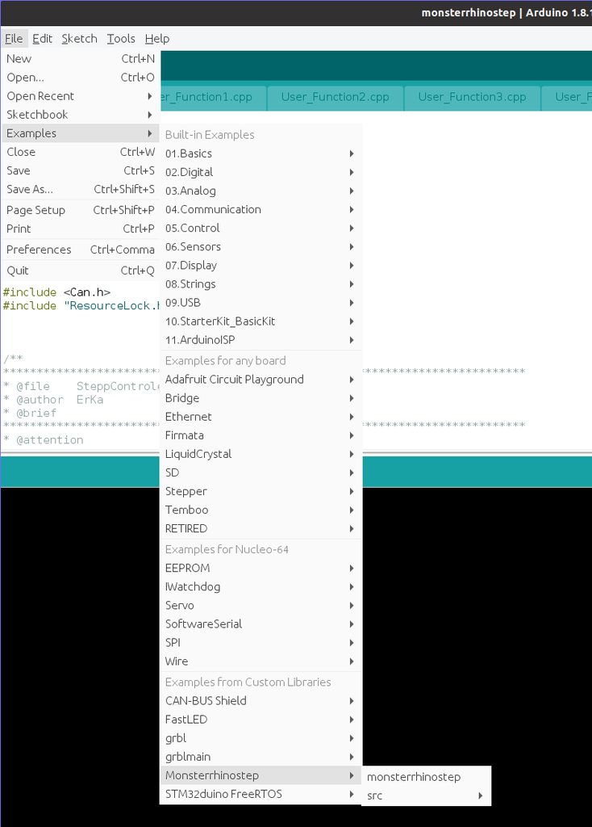

  Now you should see following files in the Arduino IDE: **monsterrhinostep**, **User_Functions1.cpp**, **User_Functions2.cpp**, **User_Functions3.cpp**, **User_Functions4.cpp**, **User_Functions5.cpp**, **User_Functions6.cpp**, **build_opt.h**.

[figure not shown]

- Before you can start you need to adjust some settings in the Arduino IDE under **Tools**:
  - Board: “Nucleo-64” **Tools -> Board .. -> STM32 Boards -> Nucleo-64**
  - Board part number: **Nucleo L476RG**
  - USB support (if available): **CDC (generic ‘Serial’ supersede U(S)ART-)**
  - Upload method: **STM32CubeProgrammer (DFU)**

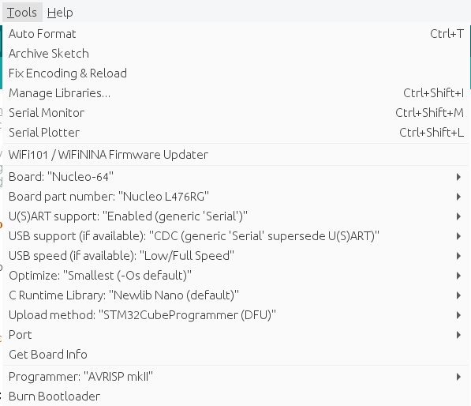

### Set up Visual Studio to use with Monsterrhino

The setup of Arduino IDE shown before has to be completed prior to setting up Visual Studio.

- Download and install Visual Studio (https://docs.microsoft.com/en-us/visualstudio/install/install-visual-studio?view=vs-2019), add the workload **desktop development with c++** during the installation process.
- Install Arduino Extension in Visual Studio: go to **Extension -> ManageExtensions -> Online**, search for **Arduino** and install **Arduino IDE for Visual Studio (Visual Micro)** (you will have to close Visual Studio during the installation process).
- Open the location configuration **Extensions -> vMicro -> General -> Configure Arduino IDE Location(s)** and enter the correct paths, it should look similar to the example in the image:

[figure not shown]

## On Ubuntu

Tested on Ubuntu 20.04.

- Install the Arduino IDE (tested with version 1.8.12)
- In the Arduino IDE go to **Properties/Additional BoardsManager** and add following

  `https://github.com/stm32duino/BoardManagerFiles/raw/master/STM32/package_stm_index.json`
- Under **Arduino/Boardsmanager** add `stm32 cores`.
- Install the Java Runtime Environment by executing the following command in your terminal `sudo apt install openjdk-8-jre`.
- Download and install the **STM32CubeProgrammer**. There might be problems with JavaFX, you can try this fix https://askubuntu.com/a/1316213.

  **Attention** Check if you can open the **STM32CubeProgrammer** and connect to your MonsterrhinoMotion. Select USB and bring your MonsterrhinoMotion into boot-mode by pressing reset while holding down the boot button. It might be usefull to open the **STM32CubeProgrammer** via the terminal, so you get some information if something is not right.

  **Note** If in your terminal you read something about **permission denied** it might be necessary to copy a rules.d file to the STM32 folder. To do so you can follow this instructions (taken from: https://community.st.com/s/question/0D53W000000aP9J/no-stm32-device-in-dfu-mode-connected):
  - Make sure you have installed this library: `sudo apt-get install libusb-1.0-0`
  - To allow STM32CubeProgrammer to access the USB port through low-level commands, proceed as follows: `cd $HOME/STM32MPU_workspace/STM32MPU-Tools/STM32CubeProgrammer-x.y.z/Drivers/rules`
  - Then execute: `sudo cp *.* /etc/udev/rules.d/`
  - Restart the STM32CubeProgrammer

  **After successfully connecting** to your device you should see something similar to:

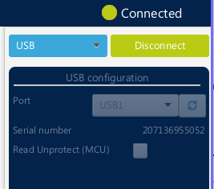

- Replace following two files on your computer with the files you find inside the https://github.com/Monsterrhino/MonsterrhinoMotion/tree/master/Library/Replace folder:
  - Replace **usbd_cdc_if.c** inside:  
    `/home/g/.arduino15/packages/STM32/hardware/stm32/1.8.0/cores/arduino/stm32/usb/cdc`
  - Replace **variant.c** inside:  
    `/home/g/.arduino15/packages/STM32/hardware/stm32/1.8.0/variants/NUCLEO_L476RG`
  - Add **Monsterrhinostep-Lib.zip** and **STM32duino_FreeRTOS.zip** to the Arduino IDE libraries from the menu **Sketch->Include Library->Add ZIP Library**.
- If you whant to use a **STM32nucleo** to program over **ST-Link** it might be necessary to give permission to the USB device (as described here: https://stackoverflow.com/questions/22713834/libusb-cannot-open-usb-device-permission-isse-netbeans-ubuntu): `sudo chmod o+w /dev/bus/usb/123/456`

## Upload from STM32Cube

If you are not able to upload your project via the Arduino IDE you can try to upload the compiled project file with STM32Cube as follows:

- Compile your project in the Arduino IDE. Go to **->Sketch->Export compiled Binary**.
- Set your MonsterrhinoMotion in boot mode and connect it via STM32CubeProgrammer (see “Install STM32CubeProgrammer”).
- Upload the compiled Hex-File to STM32CubeProgrammer with the task **->Open File** (next to Device memory).
- Press button **Download** to load your project to the device.

[figure not shown]